# ASPT (invertebrate index of trophic status)

[NO_ASPT_001]

Author

Affiliation

Hanno Sandvik

Norwegian Institute for Nature Research

Published

March 6, 2025

**Status**

This indicator documentation is incomplete and needs further developement before indicator values can be calculated.

> **Recomended citation**: Sandvik, H. 2025. ASPT (ID: NO_ASPT_001) v. 000.001. ecRxiv: https://github.com/NINAnor/ecRxiv/tree/main/indicators/NO_ASPT_001

> **Version**: 000.001

**Show metadata**

Table 1: Indicator metadata

| Indicator ID | NO_ASPT_001 |
| --- | --- |
| Indicator Name | ASPT |
| Country | Norway |
| Continent | Europe |
| Ecosystem Condition Typology Class | A2 - Chemical State characteristics |
| Realm | Freshwater (F) |
| Biome | F1 Rivers and streams biome |
| Ecosystem | F1.3 Freeze-thaw streams |
| Year added | 2025 |
| Last update | 2025 |
| status | incomplete |
| Version | 000.001 |
| Version comment | NA |
| url | https://github.com/NINAnor/ecRxiv/tree/main/indicators/NO_ASPT_001 |
| Normalised | Yes |
| Spatial aggregation pathway | Scale - Transform - Aggregate (length-weighted arithmetic mean) - Truncate |

**Logg**

- 18 Feb 2025 - Version 000.001 ready for code review
- 06 Mar 2025 - Version 000.001 revised

## 1. Summary

Freshwater ecosystems are negatively affected by anthropogenic activities that change the chemical composition of the water, such as pollution or run-off causing eutrophication and subsequent oxygen depletion. ASPT (“average score per taxon”) is a measure of the sensitivity of benthic invertebrates to the depletion of dissolved oxygen. ASPT is estimated by calculating the average sensitivity scores of the benthic macroinvertebrates sampled in a given location (Armitage et al. 1983). Rivers characterised by invertebrate communities with low sensitivity to oxygen depletion indicate a functional shift towards more disturbed ecosystems. In this way, ASPT detects eutrophication or other cases of water pollution by organic substances.

ASPT is one of the indicators that is measured and reported in connection with the *Water Framework Directive* (hereafter **WFD**). In Norway, the WFD is implemented by means of *Vannforskriften*, and relevant indicators (“parameters”, in WFD terminology) are described in national guidelines (called *Veileder 2:2018*). The data collected are archived and made available in the [*Vannmiljø*](https://vannmiljo.miljodirektoratet.no/) database.

## 2. About the underlying data

WFD data in Norway are collected in a common database called [*Vannmiljø*](https://vannmiljo.miljodirektoratet.no/), which is maintained by the [Norwegian Environment Agency](https://www.miljodirektoratet.no/). This database contains information on all *measurements* taken in connection with the WFD (“registrations”) as well as all *locations* at which measurements are taken (“water localities”). Each water locality is assigned to a *water body*. Information on water bodies can be retrieved from two other databases: the typology of water bodies is available from [*Vann-nett*](https://vann-nett.no/), whereas a geospatial dataset can be [downloaded](https://karteksport.miljodirektoratet.no/) from the Norwegian Environment Agency.

All data used are publicly available, but not all of them are machine-readable (for details, see Datasets below).

### 2.1 Spatial and temporal resolution and extent

The **spatial** resolution of WFD indicators is on the level of *water bodies*. The WFD defines a water body (specifically a “body of surface water”) as “a discrete and significant element of surface water such as a lake, a reservoir, a stream, river or canal, [or] part of a stream, river or canal” (WFD, Article 2, paragraph 10; cf. *Vannforskriften* § 3, letter a; for implementation, see *Veileder 1:2018*, ch. 2).

There is no specific **temporal** resolution, as measurements of WFD indicators are reported sporadically. Some water bodies are sampled regularly (e.g., every fifth year). For most water bodies, however, no such fixed surveillance schemes exist. Still, the total amount of measurements for many WFD indicators is sufficient to estimate annual values that are spatially aggregated to the national and regional level.

### 2.2 Original units

ASPT is calculated as a dimensionless score with possible values between 1 and 10. Zeros may be reported if no species was present in the sample analysed. However, in the connection with the WFD, values are normally reported as “normalised ecological quality ratios” (nEQR) between 0 and 1, which corresponds to *indicator* values sensu SEEA EA.

## 3. Indicator properties

### 3.1 Ecosystem Condition Typology Class (ECT)

The ECT is **A2** (chemical state) because the indicator measures the effect of organic water pollution on the benthic invertebrate fauna.

### 3.2 Ecosystem condition characteristic

Intact ecosystems are characterised by having no organic pollution, and ASPT represents the organic pollution of rivers.

### 3.3 Other standards

In the Norwegian classification of ecological characteristics (*økologiske egenskaper*) according to Nybø & Evju (2017, p. 35), the indicator represents **abiotic conditions** (*abiotiske forhold*).

In the WFD’s distinction between **quality elements**, the indicator represents the **benthic invertebrate fauna** (WFD, Annex V).

The WFD enforces the environmental **objectives** that water bodies shall not have an indicator value below X<sub>60</sub>, and that water bodies already obtaining an indicator value above X<sub>80</sub> shall not drop below this threshold (WFD, Article 4; cf. *Vannforskriften* § 4).

### 3.5 Impact factors

ASPT is affected by eutrophication, which can be the result from local or up-stream run-off (e.g. from fertilisers), direct pollution, or long distance pollution (e.g. nitrogen deposition).

## 4. Reference condition and levels

### 4.1 Reference condition

The WFD defines the reference condition of a water body as “the condition of a quality element where there is little or no human impact on the water body. The reference condition is therefore also referred to as the natural condition” (*Veileder 2:2018*, p. 17).

Reference conditions may be specific to certain water-body types. Water bodies judged to be in the reference condition are referred to as *reference water bodies*.

### 4.2 Reference levels

According to the WFD, reference levels are defined for X<sub>0</sub>, X<sub>20</sub>, X<sub>40</sub>, X<sub>60</sub>, X<sub>80</sub>, and X<sub>100</sub>. These are used to classify the “ecological status” of water bodies as “bad” (X<sub>0</sub> <= X <= X<sub>20</sub>), “poor” (X<sub>20</sub> < X <= X<sub>40</sub>), “moderate” (X<sub>40</sub> < X <= X<sub>60</sub>), “good” (X<sub>60</sub> < X <= X<sub>80</sub>), and “high” (X<sub>80</sub> < X <= X<sub>100</sub>). The WFD (Annex V, section 1.2) provides the following normative definition of “high status”: “The values of the biological quality elements for the surface water body reflect those normally associated with that type under undisturbed conditions, and show no, or only very minor, evidence of distortion.” An approach used for many WFD indicators, including this one, is to define X<sub>100</sub> as the median of the variable values measured in reference water bodies.

Reference levels for ASPT are provided in Table 5.8a of *Veileder 2:2018*. A more detailed description of the calculation of ASPT can be found in Table V5.3.3.

According to these tables, possible variable values range from 1 and 10, corresponding to a continuum from maximum eutrophication tolerance to maximum eutrophication sensitivity of the invertebrates sampled. However, Table 3.11 of *Veileder 2:2018* specifies that X<sub>0</sub> is 0, a possible interpretation of 0 being the absence of any benthic fauna. For more details, see Calculating mEQRs using reference levels below.

#### 4.2.1 Spatial resolution and validity

For ASPT, the same reference levels apply to all water bodies throughout Norway, i.e. irrespective of water-body type. The spatial resolution of WFD reference levels is the water body.

## 5. Uncertainties

The main uncertainty for national and regional values of the indicator is *sampling error*. Measurements of variable values are only sampled in a small fraction of all relevant water bodies. The approach below extrapolates indicator values to water bodies that have not been sampled, but this extrapolation is necessarily uncertain. This uncertainty is quantified using prediction intervals.

The underlying problem of the mentioned uncertainty is that the *representativeness* of the sampled water bodies for the non-sampled water bodies is unknown. A specific issue regarding representativeness is that quite some WFD measurements are taken *precisely because the sampled water body is known or assumed to be unrepresentative*. The main reasons are the following:

- Some water bodies are sampled because it is known or suspected that they do not fulfil the normative objective that X > X<sub>60</sub> (in order to justify and design measures to improve ecological condition and, later, to evaluate the effect of the measures taken).
- Some water bodies are sampled because they are regarded as reference water bodies, i.e. assumed to be in, or very close to, the reference condition.

The approach below attempts to correct for these biases by weighting measurements by the “surveillance activity” (*overvåkingsaktivitet*) during which they have been sampled. Scores between −3 and +3 have been assigned to each surveillance activity, where the sign indicates the direction of the deviation (poorer or better than a randomly chosen water body), and the absolute value is an estimate of the magnitude of the bias. The approach has been described (in Norwegian) by Sandvik (2019: pp. 17–19) and extended by Framstad et al. (2023: pp. 121–122).

## 6. References

Armitage PD, Moss D, Wright JF & Furse MT. 1983. The performance of a new biological water quality score system based on macroinvertebrates over a wide range of unpolluted running-waters. *Water Res* **17**: 333–347. [doi:10.1016/0043-1354(83)90188-4]

Framstad E, Czúcz B, Schartau AK, Simensen T, Nybø S & Sandvik H. 2023. Naturregnskap og økologisk tilstand: Samsvar mellom fagsystemet for økologisk tilstand, vannforskriften, FNs rammeverk og EUs forslag til naturregnskap. *NINA Rapp* **2327**: 1–122. [https://hdl.handle.net/11250/3104185]

Nybø S & Evju M (eds). 2017. *Fagsystem for fastsetting av god økologisk tilstand. Forslag fra et ekspertråd.* Klima- og miljødepartementet. https://www.regjeringen.no/no/dokumenter/fagsystem-for-fastsetting-av-god-okologisk-tilstand/id2558481/

Sandvik H. 2019. Ferskvann i vannforskriften og naturindeksen. Forslag til samordning og dataflyt. *NINA Rapp* **1723**: 1–38. [http://hdl.handle.net/11250/2631056]

Sandvik H. 2024. NI_vannf: dataflyt fra vannforskriften til naturindeks. https://github.com/NINAnor/NI_vannf [[doi:10.5281/zenodo.10278000](https://doi.org/10.5281/zenodo.10278000)]

United Nations et al. 2021. *System of Environmental-Economic Accounting–Ecosystem Accounting (SEEA EA).* https://seea.un.org/ecosystem-accounting

**Vannforskriften**. 2006. Forskrift om rammer for vannforvaltningen. *Nor Lovtid I* **2006**: 2004–2034. [[FOR-2006-12-15-1446](https://lovdata.no/dokument/SF/forskrift/2006-12-15-1446)]

**Veileder 1:2018**: Direktoratsgruppen for gjennomføringen av vannforskriften (ed.). 2018. *Veileder 1:2018 Karakterisering. Metodikk for å karakterisere og vurdere miljømålsoppnåelse etter vannforskriftens § 15.* Miljødirektoratet, Trondheim.

**Veileder 2:2018**: Direktoratsgruppen for gjennomføringen av vannforskriften (ed.). 2025. *Veileder for klassifisering av miljøtilstand i kyst- og ferskvann* [revised edition of *Veileder 02:2018*, version of 28 Jan 2025]. Vannportalen. https://www.vannportalen.no/veiledere/klassifiseringsveileder/

**WFD**: EU. 2000. Directive 2000/60/EC of the European Parliament and of the Council of 23 October 2000 establishing a framework for Community action in the field of water policy. *Off J EU L* **43** (327): 1–72. [[CELEX:32000L0060](http://eur-lex.europa.eu/LexUriServ/LexUriServ.do?uri=CELEX:32000L0060:en:NOT)]

## 7. Datasets

### 7.1 Vannmiljø

*Vannmiljø* is a database maintained by the [Norwegian Environment Agency](https://www.miljodirektoratet.no/) that is used to collect registrations related to ecological condition of water according to the WFD. This database contains information on all *measurements* taken in connection with the WFD (“registrations”) as well as all *locations* at which measurements are taken (“water localities”). Other information available from *Vannmiljø* includes lists of WFD variables and indicators (“parameters”), of surveillance activities, of measurement units used, of species recorded etc.

The database has long been available for manual download via https://vannmiljo.miljodirektoratet.no. Recently, the data have also been made available via an [API](https://vannmiljowebapi.miljodirektoratet.no/swagger/ui/index#/), which is utilised here.

### 7.2. Vannforekomster

In order to carry out the subsequent analyses, all WFD registrations need to be assigned to the correct water body (*vannforekomst*). Information on water bodies has currently to be downloaded from separate sources. A geospatial dataset of all water bodies is publicly available, but it needs to be downloaded manually:

- Navigate to https://karteksport.miljodirektoratet.no.
- In the menu to the left of the map, tick “Vannforekomster” in the “Produkt” section…
- …and “Nasjonalt” in the “Definer område” section.
- Click “Neste”.
- Provide your e-mail in the “Epost” box.
- Choose “ESRI Filgeodatabase (ESPG:4326)” in the “Format” box.
- Upon pressing “Send bestilling”, a compressed geodatabase (gdb) will be sent to your e-mail.

The uncompressed geodatabase is needed for the analyses. It has to have the name “VF.gdb” in order to be recognised. (A cached version called “VF.RData” is used in the demo below.)

### 7.3. Vann-nett

In addition to the location of water bodies, the subsequent analyses need information on the water body *typology*. In WFD context, typology refers to a set of factors describing abiotic characteristics of the water bodies, such as altitude, size and alkalinity. This information is publicly available from a separate database called *Vann-nett* via the link https://vann-nett.no/waterbodies/report.

A spreadsheet workbook exported from *Vann-nett* is needed for the analyses. It has to have the name “V-L.csv” (for lakes) or “V-R.csv” (for rivers) in order to recognised.

*(Note that Vann-nett has recently been upgraded. In the new version, typology factors are not included in the list of variables about water bodies that are available for export. For the time being, water body typology thus has to be based on an export from the previous version of Vann-nett, which is no longer online. It is to be hoped that the relevant information will be made available in the new version soon.)*

## 8. Spatial units

Data (measurements) are assumed to be representative for their respective water bodies, which correspond to the Ecosystem Assets of freshwater ecosystems. The Ecosystem Accounting Area covered by the data is mainland Norway.

## 9. Analyses

### 9.1. Preliminaries

At the outset, we define two variables containing the official abbreviations (i.e., according to *Vannmiljø*) of the indicator and of the relevant water category, respectively. (“Water categories” are **R**iver, **L**ake and **C**oast.)

```r
indikator <- "ASPT"
vannkategori <- "R"
```

The dataflow used here has been described in the GitHub repository [NI_vannf](https://github.com/NINAnor/NI_vannf/). We start by downloading the functions and data files from archived version 1.4 of that repo.

```r
if(!exists("../data/VF.RData")) {
  download.file("https://zenodo.org/records/11625234/files/NINAnor/NI_vannf-v1.4.zip",
                "../data/NI_vannf.zip")
  folder <- "../data/NI_vannf"
  unzip("../data/NI_vannf.zip", exdir = folder)
  while (length(list.files(folder)) == 1) {
    folder <- paste0(folder, "/", list.files(folder))
  }
  whichDataFile <- c(
    "fnr.xlsx",
    "knr.xlsx",
    "navnNVEl.csv",
    "navnVL.csv",
    "navnVM.csv",
    "navnVN.csv",
    #"NVE.RData",
    paste0("V-", vannkategori, ".csv"),
    "VF.RData",
    "VM-aktiv.xlsx",
    "VM-param.xlsx"
  )
  dummy <- file.copy(from = paste0(folder, "/data/", whichDataFile),
                     to   = "../data/",
                     overwrite = FALSE)
  dummy <- file.copy(from = paste0(folder,
                                   "/klassegr/klassegrenser_",
                                   indikator,
                                   ".xlsx"),
                     to   = "../data/",
                     overwrite = FALSE)
  dummy <- file.copy(from = list.files(paste0(folder, "/R/"), full.names = TRUE),
                     to   = ".",
                     overwrite = FALSE)
  dummy <- file.remove("../data/NI_vannf.zip")
  unlink("../data/NI_vannf", recursive = TRUE)
}
```

Next, we load the functions contained in that repo.

```r
source("Funksjon.R")
for (filnavn in list.files(".", full.names = TRUE)) {
  if (substr(filnavn, nchar(filnavn), nchar(filnavn)) %=% "R") {
    source(filnavn)
  }
}
```

### 9.2. Reading registrations and other information from Vannmiljø

Now that the preliminaries are in place, we first read the measurements of the specified indicator from the *Vannmiljø* API.

```r
DATA <- lesMaalinger(indikator, filsti = "../data")
```

```
Innlesing av 15131 vannmålinger var vellykka.
```

The output informs us that the operation was successful and how many registrations have been read.

A list of water localities (*vannlokaliteter*) is likewise read from the *Vannmiljø* API. The main function argument is the water category.

```r
VL <- lesVannlokaliteter(vannkategori, filsti = "../data")
```

```
Innlesing av 26829 vannlokaliteter var vellykka.
```

The output informs us that the operation was successful and how many water localities there are.

The function `lesMer` creates three more variables that are needed for analyses:

- `Parametere`, a data frame containing names, abbreviations and allowed values for WFD parameters (variables and indicators), read from “VM-param.xlsx”
- `Aktiviteter`, a data frame containing surveillance activities and their bias scores, read from “VM-aktiv.xlsx”
- `Enheter`, a data frame containing measurement units, read from the *Vannmiljø* API

```r
lesMer()
```

```
Innlesing av parametere, aktiviteter og enheter var vellykka.
```

### 9.3. Reading data on water bodies

The preparation of the list of water bodies (*vannforekomster*) requires two files: one containing the water body typology, which needs to be downloaded from *Vann-nett* and named “V-R.csv” (for **R**iver water bodies); and another containing a geodatabase of all water bodies, named “VF.gdb”.

```r
V <- lesVannforekomster(vannkategori, filsti = "../data")
```

```
OBS: Noen vannforekomsters humøsitet ble justert:
* 172 turbide brepåvirka vannforekomster ble satt til "klar"
* 67 turbide leirpåvirka vannforekomster ble satt til "humøs"

OBS: Noen vannforekomster har ukjente verdier for humøsitet:
* 2 med "0" = "Satt til turbid"
Disse blir satt til <NA>!

OBS: Verdien 2 av humøsitet har ulike beskrivelser:
* Humøse (30-90 mg Pt/L, TOC 5-15 mg/L)
* Satt til turbid
Dette blir ignorert!

OBS: Verdien 1 av humøsitet har ulike beskrivelser:
* Klare (< 30 mg Pt/L, TOC 2 - 5 mg/L)
* Satt til turbid
Dette blir ignorert!

OBS: Noen vannforekomster har ukjente verdier for turbiditet:
* 1 med "0" = "Ikke satt"
Disse blir satt til <NA>!

OBS: Noen vannforekomster har ukjente verdier for økologisk
     tilstand:
* 5 med "Udefinert"
Disse blir satt til <NA>!

OBS: Noen vannforekomster har ukjente verdier for økologisk
     miljømål:
* 1 med "Udefinert"
Disse blir satt til <NA>!

OBS: Noen vannforekomster har ukjente verdier for økologisk
     potensial:
Disse blir satt til <NA>!

OBS: Noen vannforekomster har ukjente verdier for økologisk
     potensial miljømål:
Disse blir satt til <NA>!

OBS: Noen vannforekomster har ukjente verdier for kjemisk
     tilstand:
* 21841 med "Udefinert"
Disse blir satt til <NA>!

Innlesing av 23343 vannforekomster var vellykka. (Men legg merke
til beskjedene over!)
```

The output informs us of several adjustments made to the data, but that the operation was successful and how many water bodies (of the relevant water category) there are.

### 9.4. Calculating mEQRs using reference levels

According to the WFD and *Veileder 2:2018*, measurements of WFD variables are transformed into so-called nEQR values (“normalised Ecological Quality Ratios”) between 0 and 1, which correspond to indicator values sensu SEEA EA. This is achieved in the following steps:

1. *Truncation.* Variable values are truncated, where measurements that are poorer than X<sub>0</sub> are set to X<sub>0</sub>, and measurements that are better than X<sub>100</sub> are set to X<sub>100</sub>.
2. *Scaling.* The truncated variable values are linearly scaled so that X<sub>0</sub> becomes 0 and X<sub>100</sub> becomes 1. The resulting indicator values are referred to as **EQR**s (“Ecological Quality Ratios”).
3. *Transformation.* EQR values are transformed in a stepwise-linear manner, so that the indicator values 0.2, 0.4, 0.6 and 0.8 correspond to the thresholds between the normative definitions of “bad”, “poor”, “moderate”, “good” and “high” ecological status according to the WFD. The resulting indicator values are referred to as **nEQR**s (“normalised EQRs”).

Truncation, however, destroys information about variation in ecological condition that is important for estimating (modelling and extrapolating) the indicator value and its uncertainty. Therefore, the dataflow from WFD to an Ecological Condition Account should be based on values that are *scaled and transformed but not truncated*. This is achieved by modifying the order of the steps from truncation–scaling–transformation to scaling–transformation–aggregation–truncation (following Sandvik 2019: pp. 13–15, Sandvik 2024):

1. *Scaling.* The *un*truncated variable values are linearly scaled so that X<sub>0</sub> becomes 0 and X<sub>100</sub> becomes 1. Note that the resulting values may be negative (if X is poorer than X<sub>0</sub>) or larger than 1 (if X is better than X<sub>100</sub>).
2. *Transformation.* The scaled values are transformed in a stepwise-linear manner in accordance with the threshold values defined by the WFD. The resulting indicator values are here referred to as **mEQR**s (“modified EQRs”). This step requires an adjustment in cases were the minimum and/or maximum values of X can be much lower or higher than X<sub>0</sub> or X<sub>100</sub>. The approach chosen here ensures that no indicator value can be below −0.2 or above 1.2.
3. *Aggregration.* Indicator values for the specific water bodies need to be spatially aggregated (see below).
4. *Truncation.* When mEQR values are truncated, they become identical to nEQR values. However, truncation is here done only after the spatial aggregation of the modelled and simulated values.

Let us have closer look at the reference levels of the indicator (which are given in *Veileder2:2018*).

```r
klassegrenser <- hentKlassegrenser("../data/klassegrenser_" %+% indikator %+% ".xlsx")
if (nrow(klassegrenser) > 1) {
  m <- matrix(0, 8, 2, dimnames = list(
    c("Minimum value:", "Range of X_" %+% seq(0, 100, 20) %+% ":", "Maximum value:"),
    c("from", "to")))
  m[, 1] <- apply(klassegrenser, 2, min, na.rm = TRUE)
  m[, 2] <- apply(klassegrenser, 2, max, na.rm = TRUE)
  klassegrenser <- klassegrenser[which(!is.na(klassegrenser[, 1]))[1], ]
} else {
  m <- t(klassegrenser)
  dimnames(m) <- list(c("Minimum", "X_0   =", "X_20  =", "X_40  =", "X_60  =",
                        "X_80  =", "X_100 =", "Maximum"), "")
}
print(m)
```

```
Minimum  0.0
X_0   =  0.0
X_20  =  4.4
X_40  =  5.2
X_60  =  6.0
X_80  =  6.8
X_100 =  6.9
Maximum 10.0
```

There is only one set of reference values for all water bodies in Norway.

The following graph shows the scaling and transformation of the indicator (using the WFD colour coding for ecological status classes).

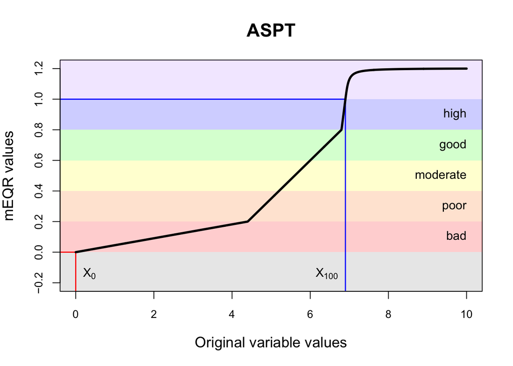

Scaling and transformation from variable measurements to mEQR values

```r
xlim <- range(klassegrenser)
xaxis <- seq(0, 10, 2)
yaxis <- seq(-0.2, 1.2, 0.2)
x <- seq(xlim[1], xlim[2], le = 1000)
y <- mEQR(x, klassegrenser)
forklar <- "Original variable values"
if (unique(DATA$enhet) %!=% "3" & exists("Enheter")) {
  forklar <- forklar %+% " (" %+%
    Enheter[which(Enheter[, 1] == unique(DATA$enhet)), 2] %+% ")"
}
plot(x, y, ty = "l", main = indikator,
     xlim = xlim,         xaxs = "r", xaxt = "n", xlab = forklar,
     ylim = c(-0.2, 1.2), yaxs = "r", yaxt = "n", ylab = "mEQR values",
     cex.main = 1.5, cex.lab = 1.2)
rect(xlim[1]-144,-0.4, xlim[2]+144, 0.0, col = rgb(0.0, 0.0, 0.0, 0.1), border = NA)
rect(xlim[1]-144, 0.0, xlim[2]+144, 0.2, col = rgb(1.0, 0.0, 0.0, 0.2), border = NA)
rect(xlim[1]-144, 0.2, xlim[2]+144, 0.4, col = rgb(1.0, 0.5, 0.0, 0.2), border = NA)
rect(xlim[1]-144, 0.4, xlim[2]+144, 0.6, col = rgb(1.0, 1.0, 0.0, 0.2), border = NA)
rect(xlim[1]-144, 0.6, xlim[2]+144, 0.8, col = rgb(0.0, 1.0, 0.0, 0.2), border = NA)
rect(xlim[1]-144, 0.8, xlim[2]+144, 1.0, col = rgb(0.0, 0.0, 1.0, 0.2), border = NA)
rect(xlim[1]-144, 1.0, xlim[2]+144, 1.4, col = rgb(0.5, 0.0, 1.0, 0.1), border = NA)
lines(c(xlim[1] - 144,    klassegrenser[7]), c(+1, 1), lwd = 1.5, col = "blue")
lines(c(klassegrenser[7], klassegrenser[7]), c(-1, 1), lwd = 1.5, col = "blue")
lines(c(xlim[1] - 144,    klassegrenser[2]), c(+0, 0), lwd = 1.5, col = "red")
lines(c(klassegrenser[2], klassegrenser[2]), c(-1, 0), lwd = 1.5, col = "red")
lines(x, y, lwd = 3)
axis(1, xaxis, erstatt(xaxis, "-", "−"), cex.axis = 0.9)
axis(2, yaxis, c("−0.2", "0.0", 0.2, 0.4, 0.6, 0.8, "1.0", 1.2), cex.axis = 0.9)
text(xlim[2], seq(0.1, 0.9, 0.2), c("bad", "poor", "moderate", "good", "high"),
     pos = 2, offset = 0)
rf <- klassegrenser[7] > klassegrenser[2]
text(klassegrenser[2], -0.15, expression(X[0]),   pos = ifelse(rf, 4, 2))
text(klassegrenser[7], -0.15, expression(X[100]), pos = ifelse(rf, 2, 4))
```

Note that variables values may be substantially larger than X<sub>100</sub> (blue line). Therefore, an asymptotic transformation is used for X > X<sub>100</sub> in order to keep mEQR values below 1.2.

### 9.5. Estimating the indicator values and their uncertainty

With the necessary files in place, the calculations can start. This is done using the function WFD2ECA (“Water Framework Directive to Ecological Condition Account”), which carries out the following steps (cf. Sandvik 2019, Sandvik 2024):

- *Removing measurements that have been taken outside the specified accounting periods.* Accounting times are assumed to be every third year. The value for 2024 is based on measurements taken in 2022, 2023 and 2024. In order to increase the sample available for modelling, earlier time periods are included as well. Accounting years chosen are 2012, 2015, 2018 and 2021, each of them representing the three years up to and including the accounting year. Measurements taken before 2010 are thus excluded.
- *Removing measurements with values that lie outside the interval for which the indicator is defined.* The *Vannmiljø* database may contain values that are incompatible with the definition of the indicator. These must have been mismeasured or misreported and need to be excluded. In addition, other measurements taken by the same operator at the same date are excluded.
- *Identifying the water locality for each measurement.* Measurements taken in an unknown water locality are excluded.
- *Identifying the water body for each water locality.* Measurements taken in an unknown water body are excluded.
- *Removing measurements that are taken in a water category for which the indicator is not defined.* For example, if a WFD indicator that is defined for rivers is measured in a lake, this measurement is excluded.
- *Removing measurements that are taken in a water body type for which the indicator is not defined.* For example, if a WFD indicator that is defined for lime-poor lakes is measured in a lime-rich lake, this measurement is excluded.
- *Removing measurements that do not fulfil specific requirements for the indicator.* Some WFD indicators need to be measured in certain months or to be derived from a certain minimum number of measurements per season. These requirements are described in *Veileder 2:2018*. Where it is possible to test whether these requirements are met based on data from *Vannmiljø*, this is done by the function.
- *Removing measurements for reporting periods with too little data.* A certain minimum sample size is needed to estimate the status for a given reporting period. If the actual sample size is smaller than this threshold, the respective reporting period is omitted, and the measurements taken during this period are excluded. The default threshold used here is 100 measurements per reporting period.
- *Scaling measurements to untruncated nEQR values (“mEQR” values).* This step is explained above.
- *Fitting a linear model to the measurements.* A linear model is fitted to the mEQR values, with explanatory variables being reporting periods, typology factors and surveillance activities. *Typology factors* of water bodies are described in *Veileder 2:2018* (especially Table 3.4) and include altitudinal zone, size class, lime content and organic matter content, among others. *Surveillance activities* describe the management target of each measurement (see [Vannmiljø](https://vannmiljokoder.miljodirektoratet.no/activity)). Measurements taken under the WFD can be expected to be biased towards poorer status than the average. Therefore, each measurement is here weighted by the representativeness of its surveillance activity, so as to partially correct for the bias in the data available (see Sandvik 2019: pp. 17–19, Framstad et al. 2023: pp. 121–122). Model selection is based on AIC ([Akaikes Information Criterion](https://en.wikipedia.org/wiki/Akaike_information_criterion)).
- *Averaging measurements taken in the same water body.* If more than one measurement has been taken in the same water body within the same reporting period, the unweighted mean of these measurements is used to represent the water body.
- *Extrapolating mEQR values to water bodies that lack data.* If no measurement has been taken in a water body, the most likely indicator value is predicted for this water body, based on the model fitted previously.
- *Using simulations to estimate confidence and prediction intervals.* Based on the model fitted and a re-sampling procedure, the uncertainty surrounding the estimates obtained in the previous steps is quantified using confidence intervals for water bodies that have been sampled, and prediction intervals for water bodies that have not been sampled. This is a time-consuming step. For illustration purposes, the number of iterations is here limited to 1,000. With so few iterations, the estimates of uncertainty are unreliable, however. For reporting one should, therefore, use more iterations, at least 10,000 (and preferably 100,000).
- *Aggregating estimates geographically.* The values obtained for water bodies are aggregated for administrative units (municipalities, counties, regions and/or the whole country). Aggregation takes the form of averages weighted by area (for lake water bodies) or length (for river water bodies). Note that this step deviates from the WFD, which does not practice aggregation. (Rather, summary statistics following the WFD are provided as the number or proportion of water bodies that fulfil the objectives of the WFD.)

The function produces summaries of the steps performed (for the time being, the information is provided in Norwegian only).

```r
utmating <- WFD2ECA(
  DATA = DATA,
  vannforekomster = V,
  vannlokaliteter = VL,
  parameter = indikator,
  vannkategori = vannkategori,
  iterasjoner = 1000,
  SEED = 479001600,
  vis = FALSE
)
```

```
   Innledende tester
   =================

De nødvendige datafilene ble funnet. Da setter vi i gang.


   Lasting av administrative enheter
   =================================

De administrative enhetene er på plass. Per 2010 fantes det 19 fylker.


   Undersøkelse av innmatingsdata
   ==============================

Det foreligger 15131 målinger av parameteren ASPT [Average Score per Taxon (ASPT)].

OBS: 679 målinger ble ekskludert fordi de ble tatt før 2010.

OBS: 30 målinger ble ekskludert fordi de ble tatt etter 2024.

Alle målinger ligger innafor parameterens definisjonsområde.

Vennligst vent mens målingene kobles mot vannforekomster!
Ferdig med 100 % av målingene.

OBS: 227 målinger ble ekskludert fordi de ikke kunne knyttes til noen kjent
     vannlokalitet.

OBS: 238 målinger ble ekskludert fordi deres vannlokaliteter ikke kunne knyttes til noen
     typifisert vannforekomst.

Alle målinger ble foretatt i den riktige vannkategorien.

Alle målinger ble foretatt i de riktige vanntypene.

OBS: 7 datapunkt måtte fjernes fra datasettet fordi de ikke oppfyller de spesifikke
     kravene som stilles til målinger av ASPT.

Dataene som inngår i modelltilpasninga, inneholder dermed
```

[output cut: 46 more lines]

```
Av disse har 23095 vannforekomster en vanntype som parameteren ASPT er definert for.
- 1 vannforekomst har den ukjente vanntypen "turbiditet = <NA>";
- 2 vannforekomster har den ukjente vanntypen "humøsitet = <NA>".
Disse blir ekskludert fra ekstrapoleringa, slik at 23092 vannforekomster er igjen.
Det foreligger altså målinger for 12 % av de relevante vannforekomstene (2863 av 23092).


   Simulering
   ==========

Nå begynner simuleringa. Det er valgt 1000 iterasjoner.
Ferdig med 100% av simuleringene.

Sånn. Da har vi omsider kommet i mål.
ASPTs mEQR-verdier har medianen 0,814 og strekker seg fra 0,642 til 1,028.
```

### 9.6. Summary of the output

The output is a list with one list element per geographic reporting level (i.e., in this case, one for the national and one for the regional level). For each geographical unit on this level and each reporting year, the predicted value and the simulated values are saved.

```r
str(utmating, give.attr = FALSE)
```

```
List of 2
 $ Norge   : num [1, 1:5, 1:1001] 0.813 0.847 0.902 0.828 0.834 ...
 $ landsdel: num [1:5, 1:5, 1:1001] 0.724 0.686 0.72 0.825 0.93 ...
```

Note that the output consists of mEQR values, i.e. it may contain values below 0 or above 1. The values thus need to be truncated in a final step. They then correspond to nEQR values sensu WFD and indicator values sensu SEEA EA.

```r
{
cat("Range of values prior to truncation (mEQR): " %+%
    format(round(min(utmating$landsdel, na.rm=TRUE), 4), nsm=4, sci=FALSE) %+%
    " to " %+%
    format(round(max(utmating$landsdel, na.rm=TRUE), 4), nsm=4, sci=FALSE) %+% "\n")
tomrom <- ifelse(nchar(format(round(min(utmating$landsdel, na.rm=TRUE), 4),
                              nsm=4, sci=FALSE)) %=% 7, " ", "")
trunker <- function(x) {
  if (is.list(x) & length(x) > 0) {
    for (i in 1:length(x)) {
      x[[i]] <- trunker(x[[i]])
    }
  } else {
    x[] <- ifelse(x[] > 1, 1, x[])
    x[] <- ifelse(x[] < 0, 0, x[])
  }
  return(x)
}
utmating <- trunker(utmating)
cat("Range of values _after_ truncation  (nEQR): " %+% tomrom %+%
    format(round(min(utmating$landsdel, na.rm=TRUE), 4), nsm=4, sci=FALSE) %+%
    " to " %+%
    format(round(max(utmating$landsdel, na.rm=TRUE), 4), nsm=4, sci=FALSE) %+% "\n")
}
```

```
Range of values prior to truncation (mEQR): 0.6418 to 1.0276
Range of values _after_ truncation  (nEQR): 0.6418 to 1.0000
```

The estimates and their confidence intervals may be summarised as tables.

```r
{
  kvantiler <- c(0.025, 0.25, 0.5, 0.75, 0.975)
  print(round(t(apply(utmating$Norge[  "Norge", , -1], 1, quantile, kvantiler)), 4))
  print(round(t(apply(utmating$landsdel[, "2024", -1], 1, quantile, kvantiler)), 4))
}
```

```
aar      2.5%    25%    50%    75%  97.5%
  2012 0.8042 0.8096 0.8126 0.8157 0.8215
  2015 0.8394 0.8445 0.8475 0.8504 0.8559
  2018 0.8949 0.8995 0.9021 0.9047 0.9097
  2021 0.8201 0.8254 0.8284 0.8314 0.8371
  2024 0.8261 0.8313 0.8343 0.8372 0.8429

landsdel       2.5%    25%    50%    75%  97.5%
  Østlandet  0.7160 0.7280 0.7347 0.7414 0.7541
  Sørlandet  0.7009 0.7154 0.7235 0.7327 0.7486
  Vestlandet 0.7187 0.7330 0.7418 0.7506 0.7696
  Midt-Norge 0.8139 0.8265 0.8341 0.8425 0.8555
  Nord-Norge 0.9442 0.9520 0.9560 0.9600 0.9678
```

## 10. Results

*NB: Please note that these results are not the final ones for 2024. The deadline for reporting WFD measurements taken in 2024 is September 2025, meaning that the values for 2024 are so far based mainly on measurements taken in 2022 and 2023.*

ASPT for Norway in different years

| Year | Best estimate | Lower quartile | Upper quartile |
| --- | --- | --- | --- |
| 2024 | 0.877 | 0.875 | 0.880 |
| 2021 | 0.838 | 0.835 | 0.841 |
| 2018 | 0.952 | 0.949 | 0.954 |
| 2015 | 0.915 | 0.912 | 0.917 |
| 2012 | 0.797 | 0.794 | 0.800 |

ASPT for regions of Norway in 2024

| Region | Best estimate | Lower quartile | Upper quartile |
| --- | --- | --- | --- |
| Østlandet | 0.784 | 0.778 | 0.790 |
| Sørlandet | 0.765 | 0.758 | 0.773 |
| Vestlandet | 0.797 | 0.789 | 0.805 |
| Midt-Norge | 0.876 | 0.869 | 0.883 |
| Nord-Norge | 0.991 | 0.987 | 0.994 |